# R 101 – 1. First Steps

Hochschule Fresenius

## Preface

## Learning Objectives

- Describe what R and RStudio are.
- Interact with R using RStudio.
- Use the various components of RStudio.
- Employ variables in R.
- Describe the various data types used in R.
- Construct data structures to store data.

## Installation Requirements

Download the most recent versions of R and RStudio for the appropriate OS using the links below:

- [R](https://cran.r-project.org/)
- [RStudio](https://www.rstudio.com/products/rstudio/download/#download)

Also see: - [R Installation and Administration Manual](https://cran.r-project.org/doc/manuals/r-release/R-admin.html) - [R Cookbook: Downloading and Installing R](https://rc2e.com/gettingstarted#recipe-id001)

If you don’t want to install R on your PC, do *CLOUD COMPUTING*:

- [RStudio Cloud](https://rstudio.cloud/)

## Sources

There are millions of good and free sources to learn R:

- [books](http://ucanalytics.com/blogs/learn-r-12-books-and-online-resources/)
- [more books](https://rstudio.com/resources/books/)
- [manuals](https://cran.r-project.org/manuals.html)
- [R for Dummies (pdf)](http://sgpwe.izt.uam.mx/files/users/uami/gma/R_for_dummies.pdf)

## Why use R?

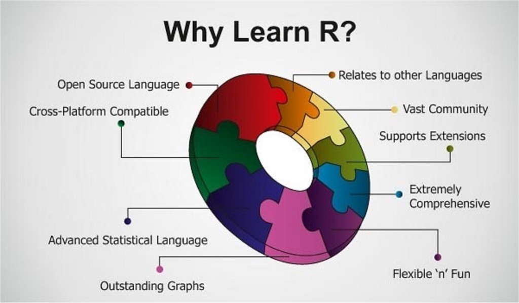

R is a powerful, extensible environment. It has a wide range of statistics and general data analysis and visualization capabilities.

- Data handling, wrangling, and storage
- Wide array of statistical methods and graphical techniques available
- Easy to install on any platform and use (and it’s free!)
- Open source with a large and growing community of peers

[figure not shown]

[figure not shown]

[figure not shown]

## RStudio

## What is RStudio?

RStudio is freely available open-source Integrated Development Environment (IDE). RStudio provides an environment with many features to make using R easier and is a great alternative to working on R in the terminal.

[figure not shown]

- Graphical user interface, not just a command prompt
- Great learning tool
- Free for academic use
- Platform agnostic
- Open source

## Creating a new project directory in RStudio

Let’s create a new project directory for our “Introduction to R” lesson today.

1. Open RStudio
2. Go to the `File` menu and select `New Project`.
3. In the `New Project` window, choose `New Directory`. Then, choose `New Project`. Name your new directory `Intro-to-R` and then “Create the project as subdirectory of:” the Desktop (or location of your choice).
4. Click on `Create Project`.
1. After your project is completed, if the project does not automatically open in RStudio, then go to the `File` menu, select `Open Project`, and choose `Intro-to-R.Rproj`.
2. When RStudio opens, you will see three panels in the window.
3. Go to the `File` menu and select `New File`, and select `R Script`. The RStudio interface should now look like the screenshot below.

## RStudio Interface

**The RStudio interface has four main panels:**

1. **Console**: where you can type commands and see output. *The console is all you would see if you ran R in the command line without RStudio.*
2. **Script editor**: where you can type out commands and save to file. You can also submit the commands to run in the console.
3. **Environment/History**: environment shows all active objects and history keeps track of all commands run in console
4. **Files/Plots/Packages/Help**

[figure not shown]

RStudio interface

## Organizing your working directory & setting up

**Viewing your working directory:** Before we organize our working directory, let’s check to see where our current working directory is located by typing into the console:

```r
getwd()
```

Your working directory should be the `Intro-to-R` folder constructed when you created the project. The working directory is where RStudio will automatically look for any files you bring in and where it will automatically save any files you create, unless otherwise specified.

## Viewing your working directory

You can visualize your working directory by selecting the `Files` tab from the **Files/Plots/Packages/Help** window.

[figure not shown]

## Setting your working directory

If you wanted to choose a different directory to be your working directory, you could navigate to a different folder in the `Files` tab, then, click on the `More` dropdown menu and select `Set As Working Directory`.

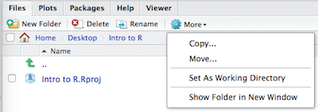

## Structuring your working directory

To organize your working directory for a particular analysis, you should separate the original data (raw data) from intermediate datasets. For instance, you may want to create a `data/` directory within your working directory that stores the raw data, and have a `results/` directory for intermediate datasets and a `figures/` directory for the plots you will generate.

Let’s create these three directories within your working directory by clicking on `New Folder` within the `Files` tab.

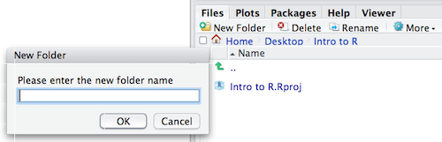

Structuring your working directory

When finished, your working directory should look like:

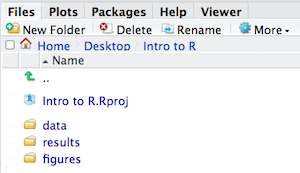

Your organized working directory

## Interacting with R

## Interacting with R

Now that we have our interface and directory structure set up, let’s start playing with R! There are **two main ways** of interacting with R in RStudio: using the **console** or by using **script editor** (plain text files that contain your code).

### Console window

The **console window** (in RStudio, the bottom left panel) is the place where R is waiting for you to tell it what to do, and where it will show the results of a command. You can type commands directly into the console, but they will be forgotten when you close the session.

## Let’s test it out:

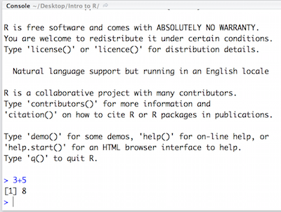

```r
3 + 5
```

## Replicability in research

One of the most important features of a scientific research paper is that the research must be replicable, which means that the paper gives readers enough detailed information that the research can be repeated (or ‘replicated’).

## Script editor

- Best practice is to enter the commands in the **script editor**, and save the script.
- You are encouraged **to comment** liberally to describe the commands you are running using `#`. This way, you have a complete record of what you did, you can easily show others how you did it and you can do it again later on if needed.
- The Rstudio script editor allows you to ‘send’ the current line or the currently highlighted text to the R console by clicking on the `Run` button in the upper-right hand corner of the script editor.
- Alternatively, you can run by simply pressing the `Ctrl` and `Enter` keys at the same time as a shortcut.

Now let’s try entering commands to the **script editor** and using the comments character `#` to add descriptions and highlighting the text to run:

```
# Intro to R Lesson
# Feb 16th, 2016

# Interacting with R

## I am adding 3 and 5. R is fun!
3+5
```

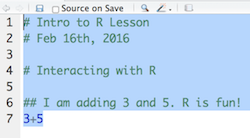

Running in the script editor

You should see the command run in the console and output the result.

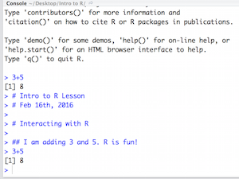

Script editor output

What happens if we do that same command without the comment symbol `#`? Re-run the command after removing the # sign in the front:

```r
I am adding 3 and 5. R is fun!
3+5
```

Now R is trying to run that sentence as a command, and it doesn’t work. We get an error in the console:

*“Error: unexpected symbol in”I am" means that the R interpreter did not know what to do with that command."*

## Console command prompt

Interpreting the command prompt can help understand when R is ready to accept commands. Below lists the different states of the command prompt and how you can exit a command:

**Console is ready to accept commands**: `>`.

If R is ready to accept commands, the R console shows a `>` prompt.

When the console receives a command (by directly typing into the console or running from the script editor (`Ctrl-Enter`), R will try to execute it.

After running, the console will show the results and come back with a new `>` prompt to wait for new commands.

**Console is waiting for you to enter more data**: `+`.

If R is still waiting for you to enter more data because it isn’t complete yet, the console will show a `+` prompt. It means that you haven’t finished entering a complete command. Often this can be due to you having not ‘closed’ a parenthesis or quotation.

**Escaping a command and getting a new prompt**: `esc`

If you’re in Rstudio and you can’t figure out why your command isn’t running, you can click inside the console window and press `esc` to escape the command and bring back a new prompt `>`.

## Interacting with data in R

## Interacting with data in R

R is commonly used for handling big data, and so it only makes sense that we learn about R in the context of some kind of relevant data. Let’s take a few minutes to add files to the folders we created and familiarize ourselves with the data.

## Adding files to your working directory

You can access the files we need for this workshop using the links provided below. If you right click on the link, and “Save link as..”. Choose `~/Desktop/Intro-to-R/data` as the destination of the file. You should now see the file appear in your working directory. **We will discuss these files a bit later in the lesson.**

- Download the **normalized counts file** [link to data](https://raw.githubusercontent.com/hbc/NGS_Data_Analysis_Course/master/sessionII/data/counts.rpkm.csv) (Hint: *right click* – *save as*)
- Download **metadata file** using [this link](https://github.com/hbc/NGS_Data_Analysis_Course/raw/master/sessionII/data/mouse_exp_design.csv)

> *NOTE:* If the files download automatically to some other location on your PC, you can move them to the your working directory using your file explorer or finder (outside RStudio), or navigating to the files in the `Files` tab of the bottom right panel of RStudio

## The dataset

- In this example dataset, we have collected whole brain samples from 12 mice and want to evaluate expression differences between them.
- The expression data represents normalized count data obtained from RNA-sequencing of the 12 brain samples.
- This data is stored in a comma separated values (CSV) file as a 2-dimensional matrix, with **each row corresponding to a gene and each column corresponding to a sample**.

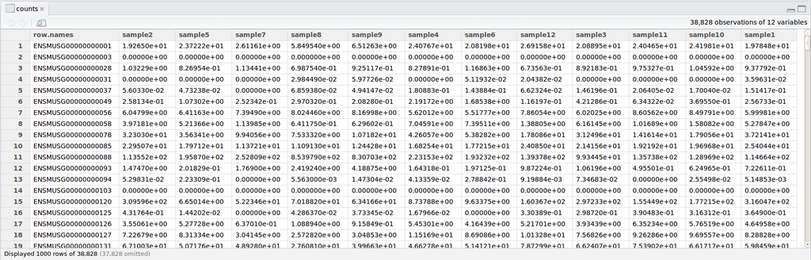

## The metadata

We have another file in which we identify **information about the data** or **metadata**. Our metadata is also stored in a CSV file. In this file, each row corresponds to a sample and each column contains some information about each sample.

- The first column contains the row names, and **note that these are identical to the column names in our expression data file above** (albeit, in a slightly different order).
- The next few columns contain information about our samples that allow us to categorize them. For example, the second column contains genotype information for each sample.
- Each sample is classified in one of two categories: Wt (wild type) or KO (knockout).
- *What types of categories do you observe in the remaining columns?*

R is particularly good at handling this type of **categorical data**. Rather than simply storing this information as text, the data is represented in a specific data structure which allows the user to sort and manipulate the data in a quick and efficient manner. We will discuss this in more detail as we go through the different lessons in R!

## Best practices

Before we move on to more complex concepts and getting familiar with the language, we want to point out a few things about best practices when working with R which will help you stay organized in the long run:

- Code and workflow are more **reproducible** if we can document everything that we do. Our end goal is not just to “do stuff”, but to do it in a way that anyone can easily and exactly replicate our workflow and results.
- All code should be written in the script editor and saved to file, rather than working in the console.
- The **R console** should be mainly used to inspect objects, test a function or get help.
- Use `#` signs to comment. **Comment liberally** in your R scripts. This will help future you and other collaborators know what each line of code (or code block) was meant to do. Anything to the right of a `#` is ignored by R. *A shortcut for this is `Ctrl + Shift + C` if you want to comment an entire chunk of text.*

## Learn how to get help

## How to get help in R and RStudio

- Click on `Help` in RStudio and see whats there
- Watch : [5 Ways to get help in R](https://youtu.be/pc7rig_cxpk)
- Watch : [Getting help in R by R-Tutorials](https://youtu.be/bPivdfjdIlY)
- Watch : [How to ask for help](https://youtu.be/ZFaWxxzouCY)

## Run your first R Script

Download this [R-Script](https://raw.githubusercontent.com/hubchev/R-Intro/master/scripts/SH-R-01.R) and try to run and use it in RStudio.

*Hint: Make a right-click and do “save as”.*

## Disclaimer

<sub><sup><sub><sup>This lesson has been developed by members of the teaching team at the [Harvard Chan Bioinformatics Core (HBC)](http://bioinformatics.sph.harvard.edu/). These are open access materials distributed under the terms of the [Creative Commons Attribution license](https://creativecommons.org/licenses/by/4.0/) (CC BY 4.0), which permits unrestricted use, distribution, and reproduction in any medium, provided the original author and source are credited.</sup></sub></sup></sub>

<sub><sup><sub><sup>The materials used in this lesson are adapted from work that is Copyright © Data Carpentry (http://datacarpentry.org/). All Data Carpentry instructional material is made available under the [Creative Commons Attribution license](https://creativecommons.org/licenses/by/4.0/) (CC BY 4.0).*</sup></sub></sup></sub>